# Locus and sample QC

Author

Jelmer Poelstra

Published

September 12, 2026

## 1 Summary

- 125 of 191 samples and 1697 of 1819 loci are retained.
- Sequencing batch is the largest technical factor: capture worked about twice as well in the 605 run, so depth-based numbers should be read by batch.
- Short (~200 bp) baits have about half the depth of long ones because of capture geometry, but give only modestly worse usable data.
- The 02b allele-balance filter blanks ~2% of evaluated hets; the pooled balance shows reference bias, not a genome-wide paralog signal.
- Paralog filters: 4 loci are dropped for excess heterozygosity and 1 on allele balance alone; all 60 sex-linked loci are dropped.
- I1495, I1507, I1624 and I1517 look like they may contain a second DNA source; none is flagged in the metadata.
- Of the 52 metadata-flagged samples, 13 have a median allele balance below 0.45, against 4 of the retained samples.
- I20937, the only *B. jabrensis*, has 10% of all singletons.

## 2 Pipeline overview

### Step 1 — Locus definition by BLAST

Probes are BLASTed against the reference genome (`01b_blast.sh`) and the hits are filtered (`01d_filter-loci.R`):

| Step | Setting | Value |
| --- | --- | --- |
| BLAST | `--top_n_query` | 5 hits per probe |
| BLAST | `--pct_id` | ≥ 90% |
| BLAST | `--pct_qcov` (HSP-based) | ≥ 80% |
| `01d_filter-loci.R` | Percent identity (`pident`) | ≥ 95% for at least one hit |
| `01d_filter-loci.R` | Query coverage (`qcovhsp`) | ≥ 90% for at least one hit |
| `01d_filter-loci.R` | Multi-hit probes | Removed entirely (probes with > 1 BLAST hit) |
| BED output | Buffer around each hit | 300 bp on each side (`buffer_size`) |

Result: 2,000 probes → 1,936 with BLAST hits → 1,819 loci.

### Step 2 — Genotype calling and consensus generation

1. Read processing and variant calling — uses the nf-core Sarek pipeline, run per sample:

| Step | Tool | Setting |
| --- | --- | --- |
| Trimming | fastp 0.24.0 | Adapter trimming, remove reads <15 bp, otherwise fastp defaults |
| Mapping | bwa-mem 0.7.18 | Default settings |
| Duplicates | GATK4 MarkDuplicates | Duplicates marked — these are then ignored by freebayes |
| Base recalibration | — | Skipped (`skip_tools: baserecalibrator`) |
| Calling regions | — | Restricted to the probe BED (`intervals`) |
| Variant calling | freebayes 1.3.10 | `--report-monomorphic --genotype-qualities`, otherwise default |

2. Genotype filtering and consensus generation — eight `bcftools` steps in `02b_bcftools-consensus.sh`:

| Step | Setting | Value | Effect |
| --- | --- | --- | --- |
| 0. Block splitting | — | — | Multi-bp monomorphic records split into one per base |
| 1. Genotype quality | `--filter_expr` | `FORMAT/DP < 5 \|\| FORMAT/GQ < 20` | Genotypes below depth/GQ set to missing (`./.`) |
| 2. Site quality | `--min_qual` | 30 | Genotypes at low-QUAL variant sites set to missing |
| 3. Indel proximity | `--snp_gap` | 5 bp | Genotypes at SNPs within 5 bp of an indel set to missing |
| 4. Normalization | `bcftools norm` | `--multiallelics -any --atomize` | Splits multiallelics and MNVs, left-aligns indels |
| 5. Indels | `bcftools view` | `-V indels` | Indels removed; SNPs only |
| 6. Allele balance | `--min_ab` / `--max_ab` | 0.25 / 0.75 | Skewed heterozygote genotypes set to missing (only where AO + RO is within 2 reads of DP, `--ab_tol`) |
| 7. Multiallelics | `--drop_multiallelic` | `true` | Positions left with >1 record after step 4 are removed |

*(Step 0 exists because freebayes occasionally merges a run of invariant positions* *into a single record (REF several bp long, ALT `.`), which can span past the end* *of the per-region reference slice given to `bcftools consensus` and crash it.)*

Consensus sequences are then generated with `bcftools consensus`, where heterozygous sites get IUPAC ambiguity codes and missing/absent genotypes become `N`.

### Step 3 — Pivot, trim, and filter consensus sequences

1. Pivot to locus-centric FASTA files (`03_pivot-fasta.sh`).
2. Per-locus trimming with ClipKIT — `03b_clipkit.sh` to remove the terminal `N` stretches caused by the buffers (terminal column is trimmed if >25% of sequences have `N` at that position).
3. Sample and locus filtering — `03c_filter-loci.sh`, applied in this order:

| Step | Parameter | Value | Effect |
| --- | --- | --- | --- |
| 1. A priori sample removal | `--remove_samples` | — | Samples flagged as contaminated in `metadata/metadata-final.tsv` |
| 2. Per-sample missingness | `max_missing_sample` | 0.1 | Samples with mean >10% `N` across all loci removed |
| 3. Minimum locus length | `min_locus_length` | 150 bp | Post-trimming alignment length |
| 4. Per-locus missingness | `max_missing_locus` | 0.2 | Loci with mean >20% `N` across retained samples removed |

*(Per-locus missingness in step 4 is recomputed after sample removal in steps* *1-2, so the locus filter is based only on retained samples. VCFs are then subset* *to the retained samples and loci.)*

### Step 4 — Sex-linked loci

Sample sex is called from the Z:autosome depth ratio, and each Z locus is classified as hemizygous, PAR-like, gametolog, or paralog, using the same per-site excess-heterozygosity statistic as step 5. **Every** sex-linked locus is currently dropped (`z_policy=all`).

### Step 5 — Paralog filter: excess heterozygosity and allele balance

Paralogous loci are detected using two tests; a locus failing either is dropped:

- The first test uses a per-site statistic `f`, the fraction of called samples that are heterozygous.
- The second uses allele balance: where one of two collapsed copies carries a variant, a het shows it on a quarter to a third of the reads rather than half, in most samples that are heterozygous there.

| Parameter | Value | Effect |
| --- | --- | --- |
| `min_call_frac` | 0.25 | A site is only scored when at least this fraction of samples has a called genotype |
| `max_het_frac` | 0.6 | A scored site with `f` above this is an ‘excess-het site’ (the HWE maximum is 0.5) |
| `max_site_frac` | 0.005 | A locus is dropped when more than this fraction of its scored sites are excess-het sites… |
| `min_het_sites` | 3 | …and it has at least this many excess-het sites |
| `min_ab_hets` | 5 | A sample counts toward a locus’s allele-balance test when it has at least this many evaluated hets there… |
| `ab_skew_cutoff` | 0.4 | …and the locus is skewed in that sample when their median allele balance is below this |
| `min_ab_samples` | 20 | A locus is only judged on allele balance with at least this many counted samples |
| `max_ab_skew_frac` | 0.5 | A locus is dropped when it is skewed in more than this fraction of counted samples |

## 3 Filtering summary

Loci and samples remaining after each filtering step:

| step | filter | n loci | n samples |
| --- | --- | --- | --- |
| input | consensus sequences from step 2 | 1,819 | 191 |
| 03c | flagged contaminant samples removed | 1,819 | 139 |
| 03c | samples with excess missingness removed | 1,819 | 125 |
| 03c | loci too short or with excess missingness | 1,762 | 125 |
| 04b | sex-linked loci removed | 1,702 | 125 |
| 04c | paralog loci removed (excess het or allele balance) | 1,697 | 125 |

Step at which each locus and sample was dropped:

| stage | n loci |
| --- | --- |
| dropped: Z (PAR-like) | 5 |
| dropped: Z (gametolog) | 4 |
| dropped: Z (hemizygous) | 50 |
| dropped: Z (paralog) | 1 |
| dropped: allele balance | 1 |
| dropped: excess het | 4 |
| dropped: missingness | 36 |
| dropped: too short | 21 |
| retained | 1,697 |

| stage | n samples |
| --- | --- |
| dropped: flagged contaminant | 52 |
| dropped: missingness | 14 |
| retained | 125 |

## 4 Depth of coverage

### Per sample

The depth figures in this section are mean FORMAT/DP over called genotypes within the retained locus intervals. These are a capture probe plus a 300-bp buffer on each side, after ClipKIT trimmed the poorly covered ends. A median of ~350 bp of buffer remains on short loci and ~310 bp on long ones. The buffer is much less deeply covered than the probe (~25x over its full width, against ~45x on short and ~70x on long probes; see *Locus lengths* below). These numbers are therefore lower than on-probe depth, and loci of different lengths are not directly comparable. Between samples the effect is small: buffer depth is 0.36–0.48 of probe depth in every sample.

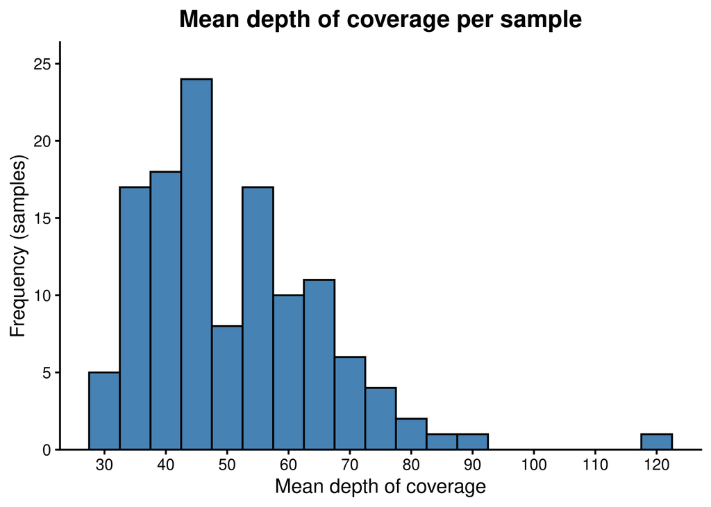

#### The depth outlier: I1767

I1767 has by far the highest depth. Looks like it was simply sequenced deeper, as other stats for this sample are not unusual. Duplication at 10.8% is the second-highest, but that makes sense given the depth.

| sample | species | mean dp | n reads | pct on target | enrichment | pct duplication | error rate | mean pct N final | ts tv | n singletons |
| --- | --- | --- | --- | --- | --- | --- | --- | --- | --- | --- |
| I1767 | jararaca | 121.7900 | 6,219,984 | 18.4940 | 130.4000 | 10.7581 | 0.0150 | 2.0840 | 2.0429 | 31 |
| I1684 | insularis | 92.0700 | 5,029,406 | 16.6870 | 117.7000 | 7.8377 | 0.0082 | 2.2927 | 1.9406 | 17 |
| I12278 | jararaca | 84.2400 | 3,017,278 | 25.3160 | 178.5000 | 7.4069 | 0.0148 | 2.4531 | 2.0160 | 202 |
| I1703 | jararaca | 81.4400 | 3,790,342 | 19.8350 | 139.9000 | 8.4778 | 0.0138 | 2.3149 | 1.9856 | 276 |
| I1793 | jararaca | 80.7700 | 2,882,232 | 25.2450 | 178.0000 | 6.5196 | 0.0149 | 2.2429 | 2.0121 | 559 |

### Per locus

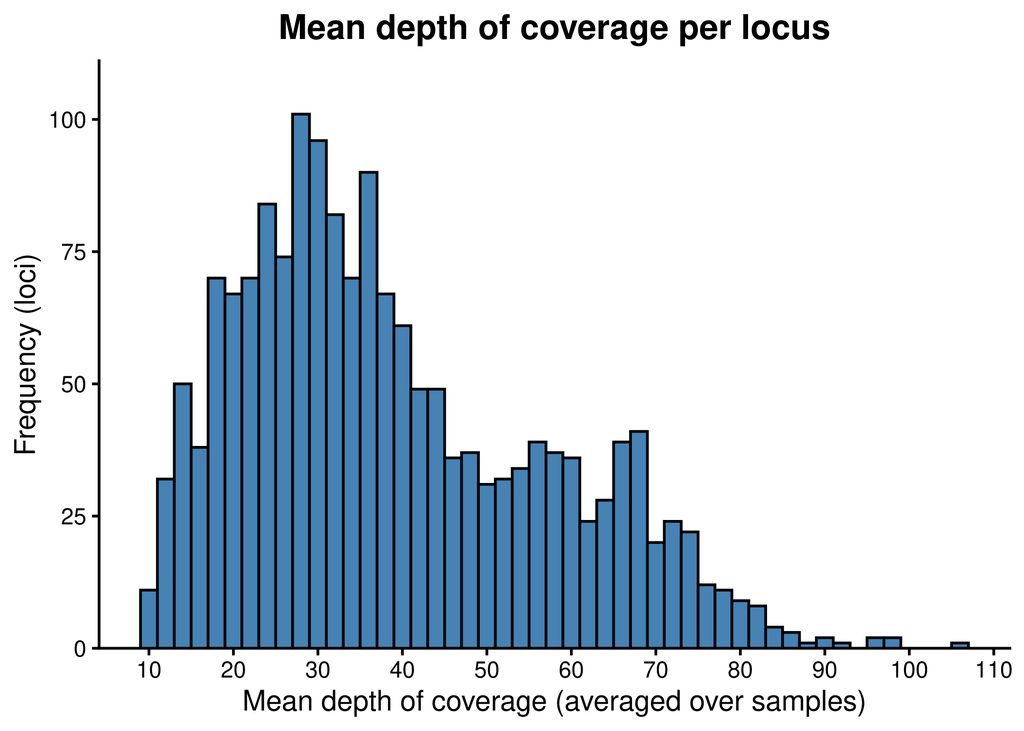

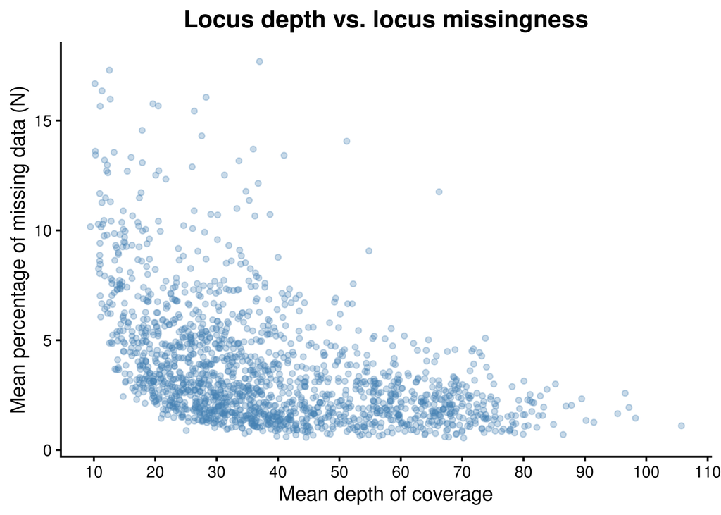

## 5 Mapping and capture

Per-sample stats:

| metric | min | median | max |
| --- | --- | --- | --- |
| n_reads | 1,488,720 | 3,091,118 | 6,546,944 |
| pct_mapped | 96.95 | 99.29 | 99.55 |
| pct_properly_paired | 89.94 | 94.02 | 96.50 |
| pct_mq0 | 4.62 | 6.86 | 9.46 |
| pct_duplication | 2.36 | 4.67 | 14.36 |
| pct_on_target | 8.68 | 15.77 | 25.44 |
| target_mean_dp | 21.29 | 34.59 | 90.44 |
| enrichment | 61.20 | 111.20 | 179.30 |

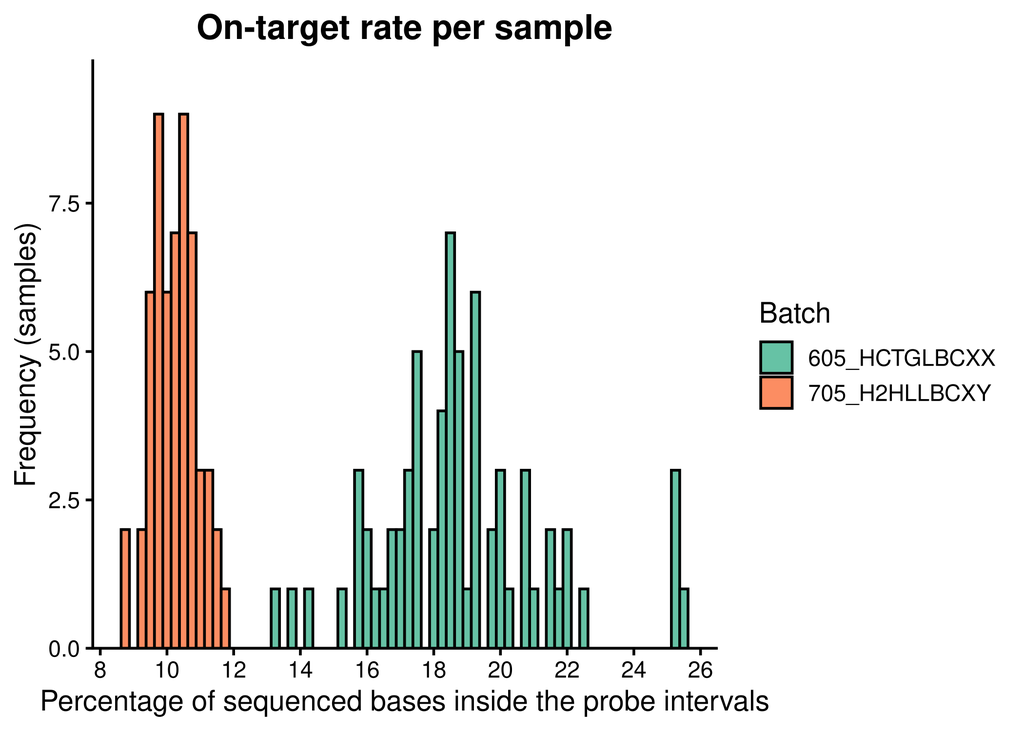

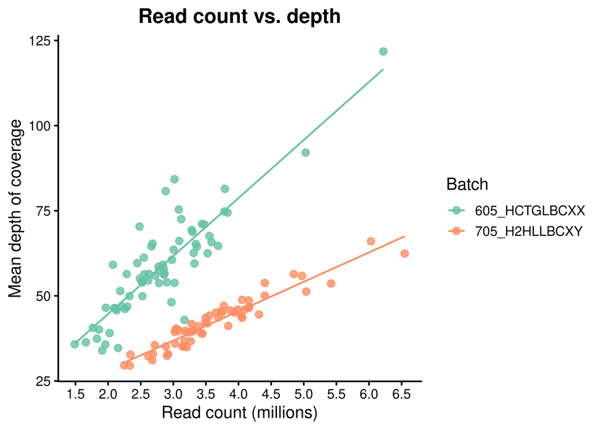

### Sequencing batch

The samples were sequenced in two runs (script 02d reads the run and flowcell from the FASTQ read names), and the capture worked about twice as well in one of them. This is the single largest structuring factor in the coverage data, so it is worth stating explicitly before any of the depth- or missingness-based numbers below are read as biology.

Per-batch means

| seq batch | n samples | n reads | pct on target | enrichment | pct duplication | mean dp | dp per Mread | mean pct N final |
| --- | --- | --- | --- | --- | --- | --- | --- | --- |
| 605_HCTGLBCXX | 68 | 2,806,035.97 | 18.79 | 132.50 | 6.16 | 58.41 | 20.82 | 3.21 |
| 705_H2HLLBCXY | 57 | 3,631,996.14 | 10.23 | 72.14 | 3.31 | 42.32 | 11.65 | 4.13 |

The mechanism is the on-target rate, and nothing else: across all retained samples, the depth a million reads buys correlates with `pct_on_target` at r = 0.998, and still at 0.988 *within* each batch. The two batches do not overlap at all on that axis, which is why the scatterplot above splits into two lines instead of one cloud.

Spread and correlations within each batch

| seq batch | n | on target min | on target max | dup min | dup max | r dp vs on target | r dp vs dup |
| --- | --- | --- | --- | --- | --- | --- | --- |
| 605_HCTGLBCXX | 68 | 13.34 | 25.44 | 4.29 | 14.36 | 0.99 | −0.10 |
| 705_H2HLLBCXY | 57 | 8.68 | 11.85 | 2.36 | 7.53 | 0.99 | −0.56 |

Two things partly offset the difference. The weaker-capture batch was sequenced about 30% deeper, and it also has the lower duplicate rate, so its samples end up down and to the right in the scatterplot rather than simply below. The net effect on the final data is real but modest: mean missingness after filtering is 3.21% in the 605 batch against 4.13% in the 705 batch, and the number of loci called per sample is essentially identical between them (mean 1695 and 1695 of 1697, with a per-sample minimum of 1686 and 1684).

Batch is not confounded with the main biological groupings: the split is close to even for *jararaca* and for the mainland samples. It is not even, however, for the island endemics — *insularis* and *sazimai* were sequenced only in the 605 batch and most *alcatraz* samples in the 705 batch — so any between-species comparison of a coverage-derived quantity should be checked against this table.

Samples per land type, species and batch

| land type | species | 605 HCTGLBCXX | 705 H2HLLBCXY |
| --- | --- | --- | --- |
| island | alcatraz | 1 | 6 |
| island | germanoi | 1 | 0 |
| island | insularis | 6 | 0 |
| island | jararaca | 2 | 0 |
| island | sazimai | 5 | 0 |
| mainland | jabrensis | 0 | 1 |
| mainland | jararaca | 53 | 50 |

One sample crosses over: `I1619` was sequenced in the 605 batch but sits with the 705 cloud. It has the highest duplicate rate in the data set (14.4%) on top of the lowest on-target rate of its own batch.

Batch also affects which samples survive filtering: of the 14 samples dropped for missingness in 03c, 10 are from the 705 batch.

Samples retained and dropped for missingness, per batch

| seq batch | dropped: missingness | retained |
| --- | --- | --- |
| 605_HCTGLBCXX | 4 | 68 |
| 705_H2HLLBCXY | 10 | 57 |

## 6 Locus lengths

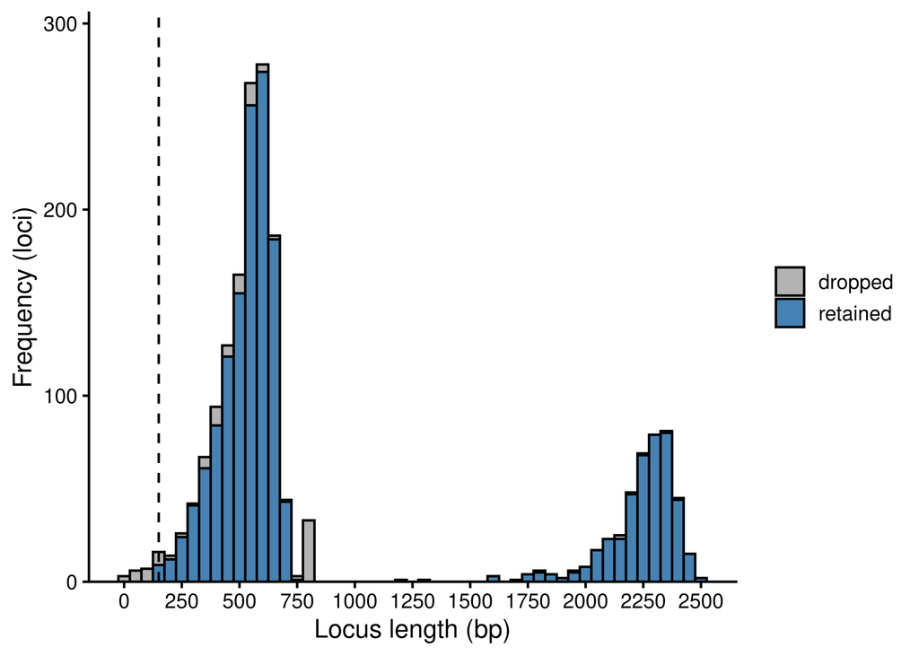

Length and depth go together (r = 0.85), for two reasons.

The first is capture geometry. A locus is one bait plus 300 bp of buffer on each side, and the baits come in two sizes, ~200 and ~1,950 bp. The buffer is covered at ~25x and makes up three quarters of a short interval but under a quarter of a long one. On the bait itself, capture efficiency ramps up over the first ~300 bp from its edge (script 04g, below), so a ~200-bp bait never reaches the plateau that long baits hold.

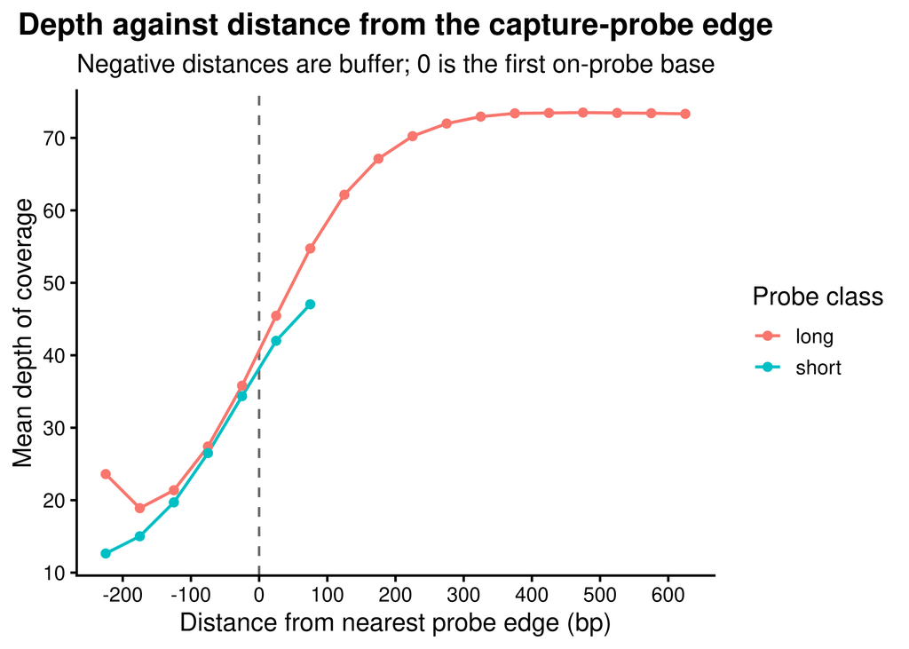

The second is trimming, where depth sets length rather than the reverse: ClipKIT removes mostly-`N` ends, so a poorly covered locus finishes short (`pct_trimmed` vs. depth r = -0.84). Within the short class, where every locus starts from the same 800-bp interval, final length still tracks depth (r = 0.82).

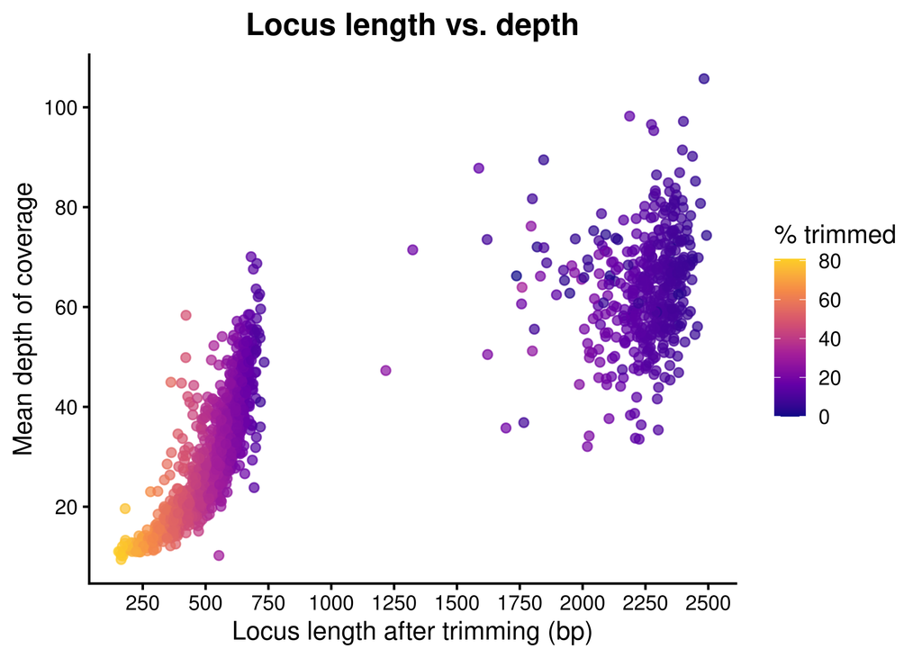

Median depth is 29.8 for loci under 1,000 bp (n = 1265) against 63.8 for the longer ones (n = 432), but that gap overstates the difference in usable data: the low-depth buffer is largely what ClipKIT trims away. After trimming, the short loci are only modestly worse — median call fraction 0.967 against 0.979, and 0.77 against 0.93 for the worst sample at each locus — and their per-base informativeness is similar (median `prop_variable` 0.064 against 0.064). They contribute fewer parsimony-informative sites (median 22 against 94) because they are shorter, not because they are called less well.

## 7 End trimming

ClipKIT (script 03b) removed terminal columns that were mostly N, and script 03d tabulated how much went per locus. The buffer is at most 75% of an interval (600 of 800 bp for a short locus), so a locus trimmed by 80-99% also lost part of its probe: what remains is short and usually poorly covered.

Loci where ClipKIT failed (`trim_failed`) were left untrimmed and show up at 0%; it failed because missing data was high across the whole locus.

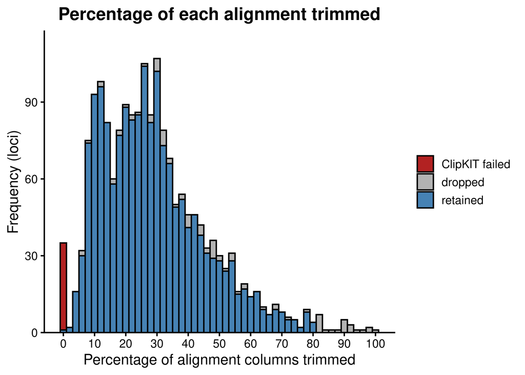

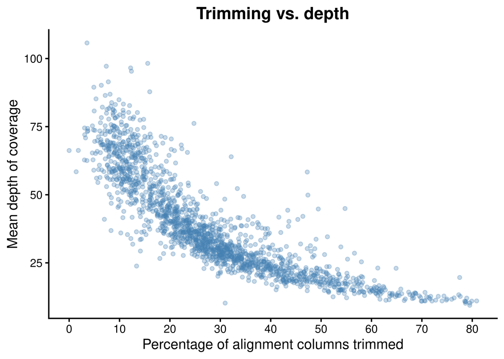

## 8 Missingness

### Per locus

Missingness is shown here for every locus that entered step 3, including the ones later dropped, so that the `max_missing_locus` threshold (20%) is visible instead of cutting the distribution off at its own value. Loci are colored by where they left the pipeline, since the ones dropped for length, sex linkage, excess heterozygosity or allele balance are not a comment on missingness:

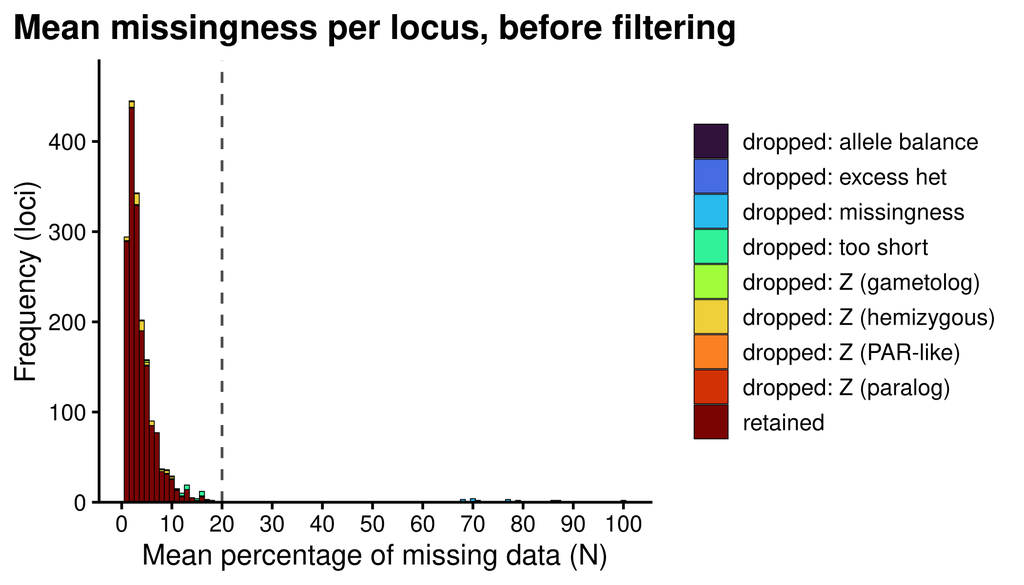

### Per sample

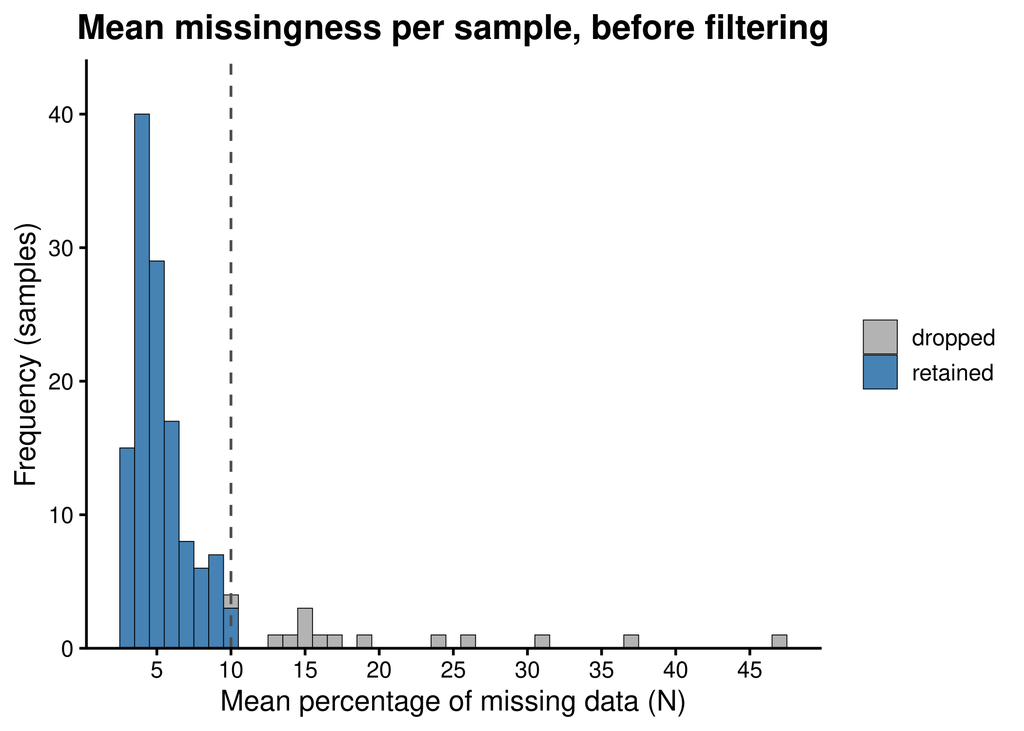

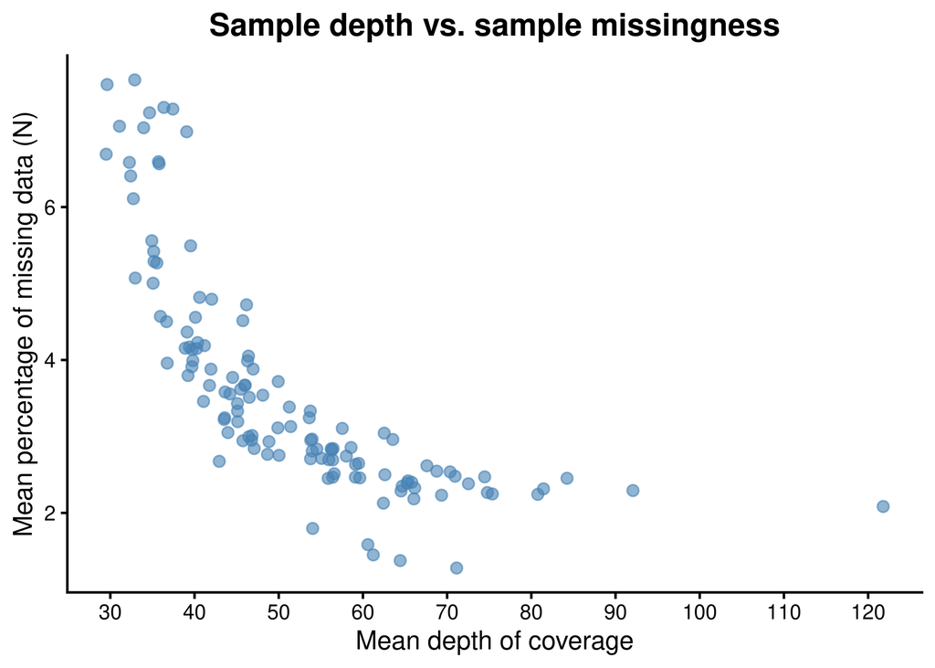

## 9 Sample sex

Snakes are ZW, so females are hemizygous over the differentiated part of the Z and show about half the male depth there.

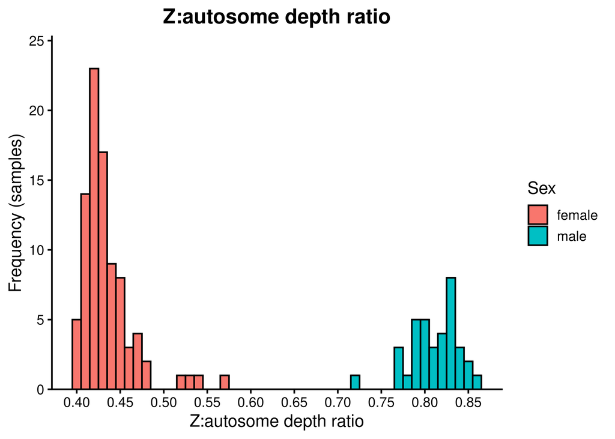

| sex | sex confident | n |
| --- | --- | --- |
| female | FALSE | 5 |
| female | TRUE | 84 |
| male | FALSE | 2 |
| male | TRUE | 34 |

Sex is assigned by splitting the sorted depth ratios at their largest internal gap, so every sample gets a call however intermediate its ratio is. The confidence flag is what marks the shaky ones: three statistics — the depth ratio, heterozygosity over the hemizygous Z, and the number of heterozygous gametolog sites — are z-scored within the assigned sex group using the median and a MAD-based SD, and a sample exceeding `max_group_z` (3) on any of them is flagged, as is any sample below `min_auto_dp` (15) autosomal depth.

Samples whose sex could not be called with confidence:

| sample | species | mean dp | z depth ratio | z het density | n het gametolog | sex | sex flags |
| --- | --- | --- | --- | --- | --- | --- | --- |
| I1671 | jararaca | 39.2300 | 0.4802 | 0.0006 | 160 | female | depth_ratio(z=3.1) |
| I20937 | jabrensis | 32.9000 | 0.5167 | 0.0010 | 146 | female | depth_ratio(z=5.2) |
| I1507 | jararaca | 33.9600 | 0.5320 | 0.0022 | 144 | female | depth_ratio(z=6.1) |
| I1795 | jararaca | 53.7500 | 0.5413 | 0.0012 | 178 | female | depth_ratio(z=6.7) |
| I1495 | jararaca | 57.5500 | 0.5692 | 0.0038 | 132 | female | depth_ratio(z=8.3) |
| I1624 | jararaca | 39.5400 | 0.7158 | 0.0034 | 23 | male | depth_ratio(z=4.2),gametolog_hets(z=5.1) |
| I12279 | alcatraz | 62.4300 | 0.8630 | 0.0003 | 5 | male | het_density(z=3.1) |

Most flagged samples are females whose depth ratio sits between the two modes, which the gap split has to assign to one side; the `sex_flags` column shows which statistic flagged each sample.

## 10 Excess heterozygosity

This is one of the two paralog tests in 04c (the other is allele balance, below). A locus is dropped as a likely collapsed paralog when more than 0.5% of its scored sites (`max_site_frac`), and at least 3 sites (`min_het_sites`), are heterozygous in more than 60% of called samples (`max_het_frac`, against a maximum of 0.5 under HWE). For those thresholds to be meaningful the flagged loci should stand apart rather than form the tail of a continuous distribution.

Note that the `pct_max_site_het` column below is the *observed* maximum across the sites of a locus, not the threshold.

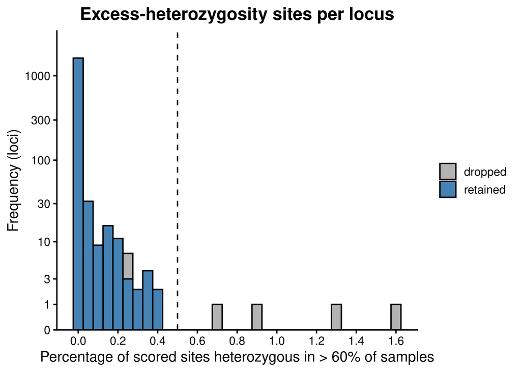

The filter is not driven by one sequencing batch: all four dropped loci are elevated in both, at 2-4x the batch’s own panel mean (L1306 1.03/1.04, L1813 1.49/1.56, L663 1.40/1.38, L473 1.32/0.90 for 705/605, against panel means of 0.38 and 0.42).

The loci dropped for excess heterozygosity, with the ones just below the threshold for comparison. `excess_site_frac` and `het_density` are small fractions, so these are shown as percentages:

| locus | stage | length | n sites het scored | n excess sites | pct excess sites | pct max site het | pct het density |
| --- | --- | --- | --- | --- | --- | --- | --- |
| L1813 | dropped: excess het | 2,140 | 2,112 | 27 | 1.28 | 87.07 | 1.34 |
| L473 | dropped: excess het | 649 | 630 | 10 | 1.59 | 77.78 | 1.00 |
| L1826 | dropped: allele balance | 2,329 | 2,288 | 6 | 0.26 | 77.98 | 0.68 |
| L1306 | dropped: excess het | 571 | 568 | 5 | 0.88 | 78.18 | 0.99 |
| L1652 | retained | 2,327 | 2,306 | 5 | 0.22 | 84.38 | 0.30 |
| L1727 | retained | 2,318 | 2,291 | 5 | 0.22 | 66.67 | 0.45 |
| L663 | dropped: excess het | 758 | 734 | 5 | 0.68 | 94.87 | 1.24 |
| L1720 | retained | 2,284 | 2,281 | 4 | 0.18 | 62.16 | 0.34 |
| L1789 | retained | 2,359 | 2,333 | 3 | 0.13 | 65.71 | 0.53 |
| L1805 | retained | 2,350 | 2,302 | 3 | 0.13 | 70.27 | 0.59 |
| L1914 | retained | 2,381 | 2,353 | 3 | 0.13 | 88.89 | 0.71 |
| L1916 | retained | 2,308 | 2,258 | 3 | 0.13 | 64.58 | 0.52 |
| L1003 | retained | 582 | 568 | 2 | 0.35 | 72.73 | 0.61 |
| L1142 | retained | 564 | 536 | 2 | 0.37 | 78.95 | 0.28 |
| L1662 | retained | 2,350 | 2,311 | 2 | 0.09 | 74.19 | 0.45 |

## 11 Allele balance

Step 6 of 02b sets a heterozygous genotype to missing when its allele balance, AO / (AO + RO), falls outside 0.25-0.75. The filtered VCFs cannot show what that removed, because a blanked genotype looks like any other missing one, so script 04h replays the 02b filter chain on the raw VCFs and records every het that reaches step 6. It reproduces the filtered VCFs exactly (checked position by position for one sample: every ‘kept’ and ‘exempt’ het is a het there, every ‘blanked’ one is missing).

Allele balance is a ratio, so unlike the depth figures above it does not depend on where in the locus a site sits. Everything below is restricted to the retained samples.

Het genotypes at the allele-balance step, retained loci

| status | n | pct |
| --- | --- | --- |
| blanked | 15,237 | 1.89 |
| exempt | 64,827 | 8.03 |
| kept | 727,710 | 90.09 |

Why exempt hets were not evaluated

| reason | n | pct |
| --- | --- | --- |
| RO = 0 (split multiallelic) | 48,340 | 74.57 |
| AO + RO off DP by > 2 reads | 16,487 | 25.43 |

‘Exempt’ hets are on records where AO + RO differs from DP by more than 2 reads (`--ab_tol`), which 02b skips on purpose: after multiallelic splitting, one half of a real 1/2 genotype shows no reference reads and would otherwise be thrown out. That case is 75% of exempt hets, and in total the filter does not look at 8.0% of hets.

### Distribution

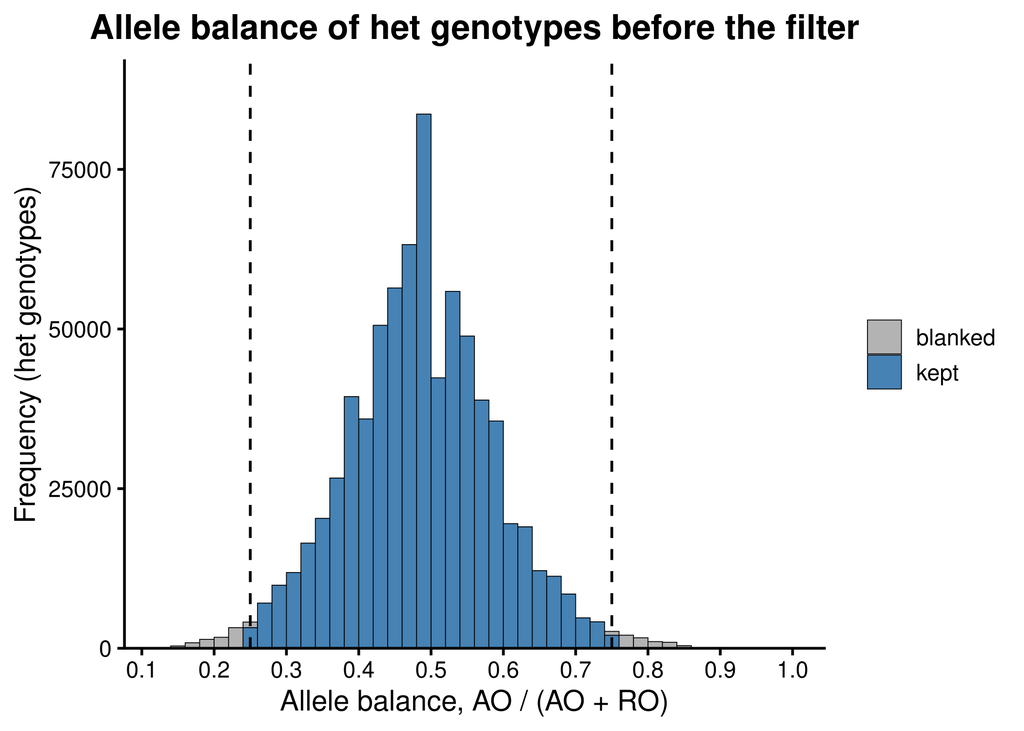

Evaluated hets by genotype depth, retained loci

| depth | n het | median ab | pct below 0.35 | pct above 0.65 | pct blanked |
| --- | --- | --- | --- | --- | --- |
| 5-10 | 24,268 | 0.50 | 6.33 | 9.58 | 0.19 |
| 11-20 | 104,792 | 0.50 | 11.94 | 10.20 | 1.08 |
| 21-40 | 197,283 | 0.48 | 12.28 | 7.75 | 2.94 |
| 41-80 | 281,255 | 0.49 | 7.41 | 3.91 | 2.10 |
| > 80 | 135,349 | 0.49 | 3.95 | 1.96 | 1.74 |

The distribution has a single mode at 0.5 and leans to the reference side: 8.7% of hets are below 0.35 against 5.6% above 0.65. That is the usual reference bias of mapping to a reference, which favors reads that match it, and it is strongest at moderate depth. There is no second mode near 0.25, so paralogs are not a problem at the level of the whole data set; they show up per locus (below). Overall, the filter removes 2.1% of evaluated hets.

### Per sample

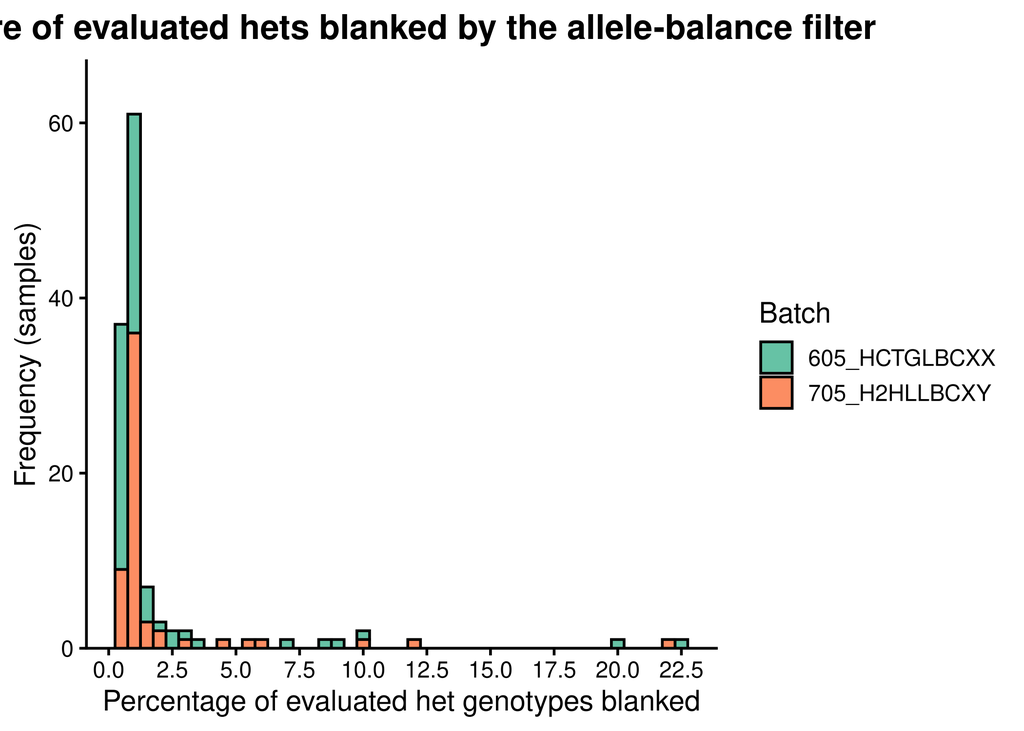

Samples with the most hets blanked

| sample | species | seq batch | n evaluated | pct blanked | median ab | pct below 0.35 | pct above 0.65 | mean dp | n transitions | n singletons |
| --- | --- | --- | --- | --- | --- | --- | --- | --- | --- | --- |
| I1768 | jararaca | 605_HCTGLBCXX | 4,623 | 22.60 | 0.47 | 15.64 | 21.46 | 63.55 | 5,454 | 22 |
| I1670 | jararaca | 705_H2HLLBCXY | 6,634 | 22.04 | 0.49 | 25.63 | 30.57 | 46.03 | 5,159 | 19 |
| I1684 | insularis | 605_HCTGLBCXX | 3,346 | 19.93 | 0.48 | 20.53 | 7.56 | 92.07 | 2,583 | 17 |
| I1624 | jararaca | 705_H2HLLBCXY | 7,775 | 12.23 | 0.43 | 27.86 | 11.50 | 39.54 | 6,812 | 312 |
| I1517 | jararaca | 705_H2HLLBCXY | 10,013 | 10.13 | 0.38 | 40.26 | 14.81 | 45.10 | 8,740 | 367 |
| I1495 | jararaca | 605_HCTGLBCXX | 9,969 | 10.08 | 0.37 | 42.66 | 15.14 | 57.55 | 8,852 | 502 |
| I1507 | jararaca | 605_HCTGLBCXX | 7,619 | 9.03 | 0.44 | 23.39 | 9.29 | 33.96 | 7,189 | 376 |
| I1728 | sazimai | 605_HCTGLBCXX | 4,260 | 8.52 | 0.48 | 14.48 | 10.05 | 46.51 | 6,802 | 44 |

The typical sample loses 0.9% of its evaluated hets (IQR 0.7-1.1%), and the share is unrelated to depth (r = 0.05). The samples well above that come in two kinds:

- **Widened balance: I1768, I1670, I1684.** About a fifth of their hets are blanked, and their median balance is still close to 0.5. For I1768 and I1670 both ends of the window lose hets about equally; I1684 loses more on the low side. Depth is not low (I1684 has the second-highest in the panel), and duplication, error rate, and insert size are ordinary. What the three share is a low variant count: they are among the samples with the fewest transitions and have very few singletons. A second DNA source would skew balance to one side, which the first two do not show, and the cause is not clear from the metrics in this report.
- **Skewed low: I1495, I1517, and less strongly I1624 and I1507.** The first two have a median balance below 0.4 with about 40% of their hets under 0.35; I1624 and I1507 are at 0.43-0.44 with a quarter of their hets under 0.35. That is what a minor second source of DNA does: the contaminant’s alleles appear as hets supported by a minority of reads. All four have more singletons than the median sample (307), and three of them also fail sex calling (see *Samples to watch*). None is among the samples flagged as contaminated in the metadata.

### Per locus

Pooling all hets at a locus lets a few low-coverage samples dominate its share of blanked hets, so loci are scored per sample instead. For each sample with at least 5 evaluated hets at a locus, the locus is ‘skewed’ in that sample if the median balance is below 0.4. A collapsed paralog should be skewed in most samples that are heterozygous there; a locus with a few noisy samples should not.

Share of samples in which a locus is skewed, by locus fate (loci with >= 20 counted samples)

| stage | n loci | median pct skewed | max pct skewed |
| --- | --- | --- | --- |
| dropped: Z (paralog) | 1 | 71.79 | 71.79 |
| dropped: allele balance | 1 | 67.54 | 67.54 |
| dropped: excess het | 4 | 44.17 | 68.42 |
| dropped: Z (gametolog) | 4 | 41.21 | 51.61 |
| dropped: Z (PAR-like) | 4 | 13.38 | 15.22 |
| dropped: Z (hemizygous) | 4 | 10.17 | 21.74 |
| retained | 838 | 6.67 | 48.65 |

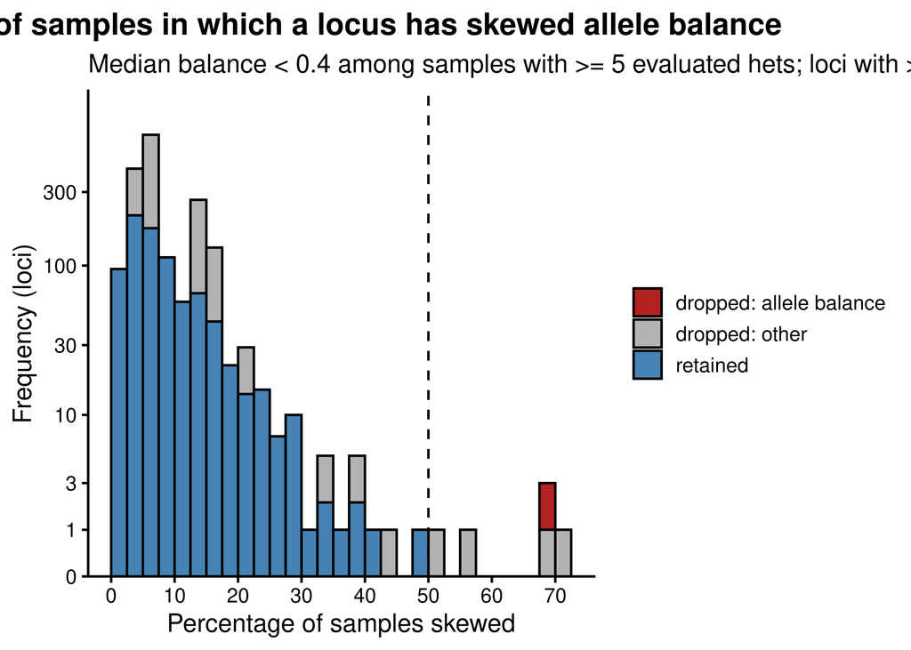

Loci skewed in the largest share of samples

| locus | stage | n samples | n skewed | pct skewed | n het | median ab | pct blanked | mean dp | n excess sites |
| --- | --- | --- | --- | --- | --- | --- | --- | --- | --- |
| L1839 | dropped: Z (paralog) | 117 | 84 | 71.79 | 4,028 | 0.33 | 32.82 | 151.95 | – |
| L1813 | dropped: excess het | 114 | 78 | 68.42 | 4,333 | 0.35 | 29.45 | 155.42 | 27 |
| L1826 | dropped: allele balance | 114 | 77 | 67.54 | 2,505 | 0.36 | 24.07 | 129.17 | 6 |
| L473 | dropped: excess het | 61 | 34 | 55.74 | 819 | 0.39 | 2.44 | 26.18 | 10 |
| L879 | dropped: Z (gametolog) | 93 | 48 | 51.61 | 1,740 | 0.40 | 5.98 | 22.71 | – |
| L10 | retained | 74 | 36 | 48.65 | 827 | 0.41 | 9.07 | 38.05 | 0 |
| L489 | dropped: Z (gametolog) | 91 | 40 | 43.96 | 2,525 | 0.41 | 2.53 | 41.57 | – |
| L416 | retained | 41 | 17 | 41.46 | 399 | 0.43 | 7.77 | 17.36 | 0 |
| L91 | retained | 35 | 14 | 40.00 | 326 | 0.47 | 7.36 | 28.17 | 0 |
| L1236 | retained | 23 | 9 | 39.13 | 325 | 0.47 | 1.54 | 14.72 | 0 |
| L918 | dropped: Z (gametolog) | 78 | 30 | 38.46 | 925 | 0.44 | 1.95 | 17.80 | – |
| L1336 | retained | 43 | 16 | 37.21 | 481 | 0.46 | 2.29 | 26.26 | 0 |
| L198 | retained | 21 | 7 | 33.33 | 261 | 0.46 | 3.45 | 25.26 | 0 |
| L1047 | retained | 27 | 9 | 33.33 | 323 | 0.47 | 2.17 | 37.11 | 0 |
| L1306 | dropped: excess het | 92 | 30 | 32.61 | 732 | 0.45 | 8.61 | 36.28 | 5 |

Loci that 04b dropped as Z paralogs or gametologs, which this measure did not select, also sit at the top, and the typical retained locus is skewed in 7% of samples, with 99% of retained loci at or below 30%.

**L1826 is dropped by the allele-balance test alone.** It is skewed in 68% of 114 samples, alongside L1839 (dropped as a Z paralog, 72%) and L1813 (dropped for excess heterozygosity, 68%). Like those two, it has about twice the depth of a typical long locus (129x, against a long-class median of 64x), and its 6 excess-het sites are too few for the excess-het test. Balance near 0.25-0.35 at the same sites across dozens of samples is what one variable copy of two looks like.

L10 is the most skewed retained locus (49% of 74 samples), but its depth is ordinary for a short locus and it has no excess-het sites.

## 12 Locus informativeness

The per-sample genotype counts in 05c measure how far each sample sits from the reference, which says nothing about whether a locus separates the samples from each other. Script 04e counts, over the 125 retained samples, the sites that are variable among them and the subset that are parsimony-informative — where each of the two alleles is carried by at least two samples, so the site can support a grouping.

| n sites scored | n variable | n pi | n singleton | pct variable | pct pi |
| --- | --- | --- | --- | --- | --- |
| 1,620,720 | 104,640 | 69,251 | 35,389 | 6.46 | 4.27 |

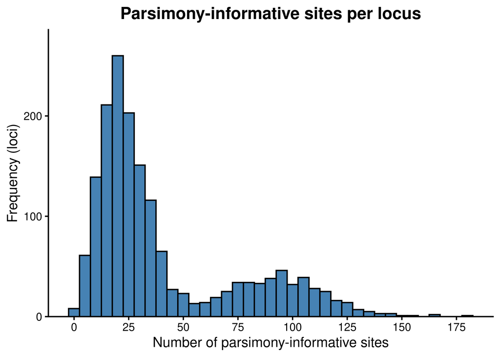

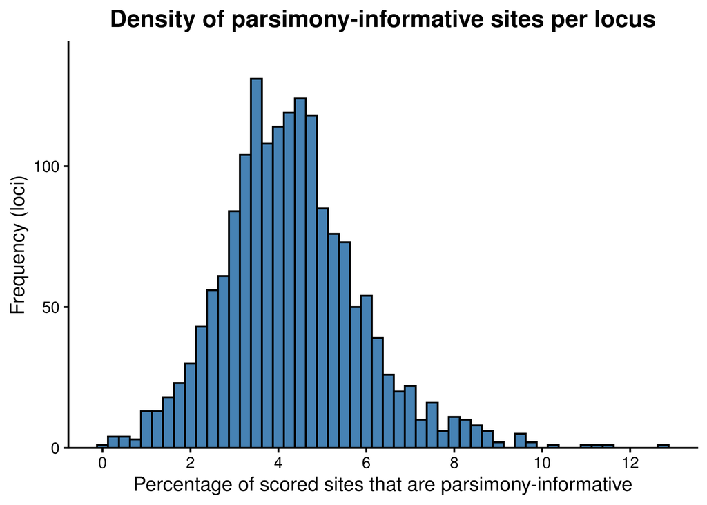

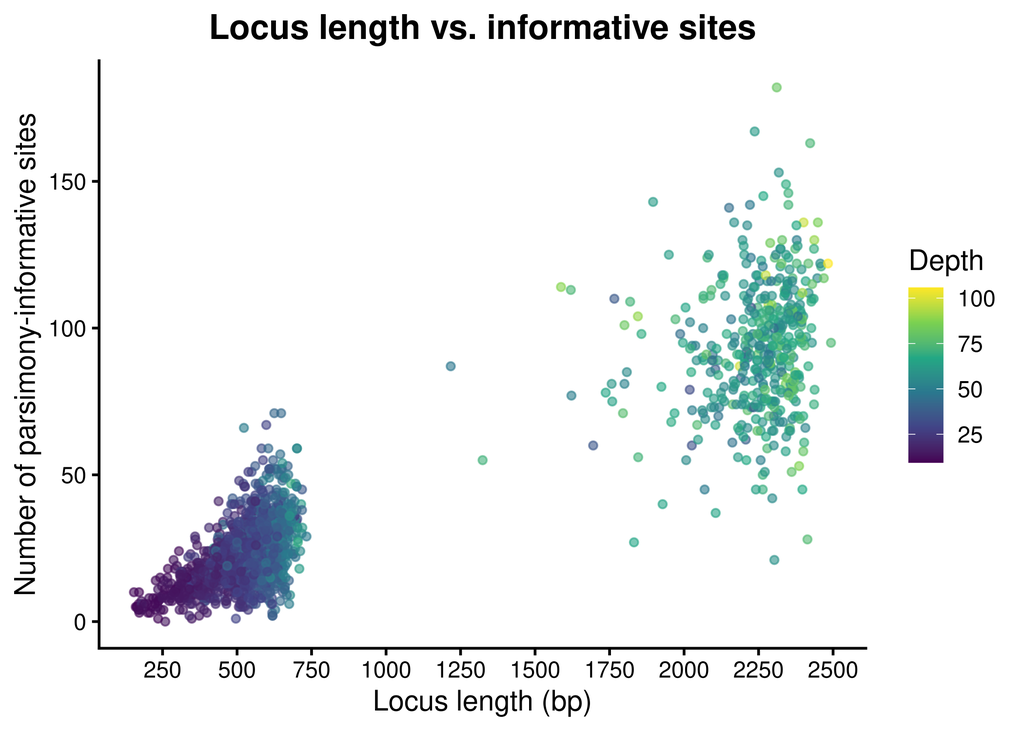

## 13 Heterozygosity per sample

Heterozygosity is the readout the downstream comparisons in 05c are built on, so it is worth checking here that it is not being set by depth instead of by biology. At low depth one allele of a true heterozygote can go unobserved, and the genotype is then called homozygous — allele dropout, which biases heterozygosity down exactly where coverage is worst.

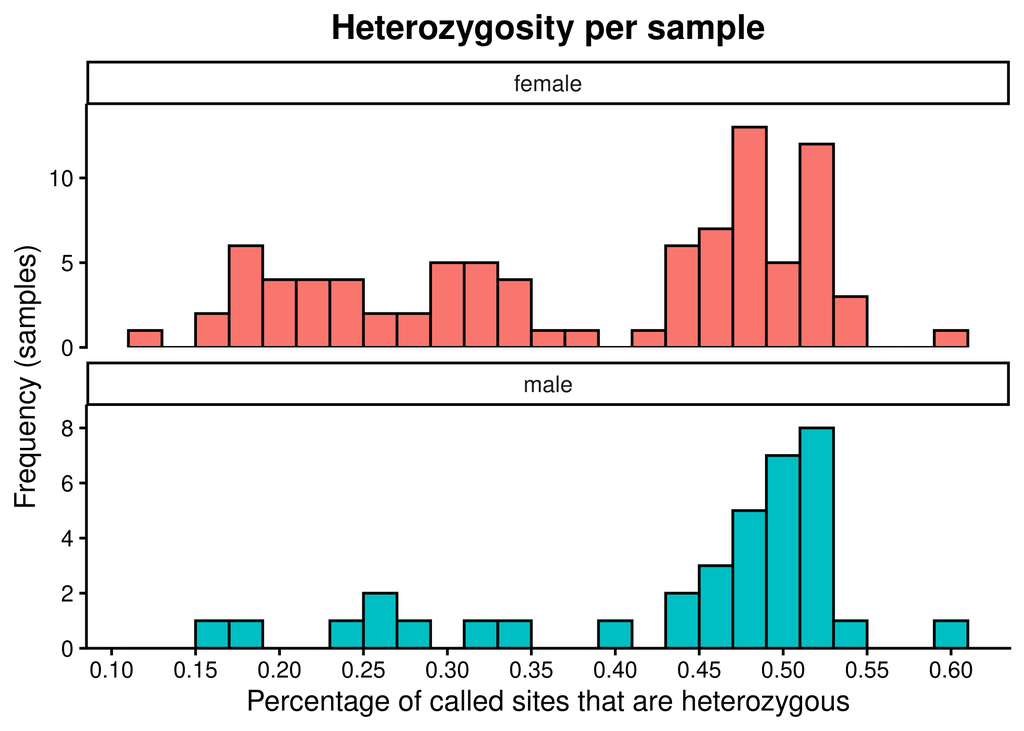

Both panels are bimodal in the same place, and the split follows species and locality, not sex. The low cluster is every non-*jararaca* sample (medians 0.12-0.24%, all 20 of them below 0.40%) plus 29 *jararaca*; the high cluster is *jararaca* only. Within *jararaca*, heterozygosity varies with sampling locality (see *Heterozygosity and sequencing batch*).

| species | n | median pct het | min | max |
| --- | --- | --- | --- | --- |
| germanoi | 1 | 0.118 | 0.118 | 0.118 |
| alcatraz | 7 | 0.171 | 0.157 | 0.181 |
| jabrensis | 1 | 0.181 | 0.181 | 0.181 |
| insularis | 6 | 0.193 | 0.173 | 0.218 |
| sazimai | 5 | 0.237 | 0.222 | 0.266 |
| jararaca | 105 | 0.473 | 0.202 | 0.594 |

Either slope is a warning, and they mean opposite things. Rising with depth points to allele dropout, heterozygosity being lost where coverage is thin. Falling with depth points the other way: whatever inflates heterozygosity in these samples is concentrated in the ones that sequenced worst, which is the pattern a mixed or contaminated sample produces. Either way a comparison between groups that differ in depth is confounded.

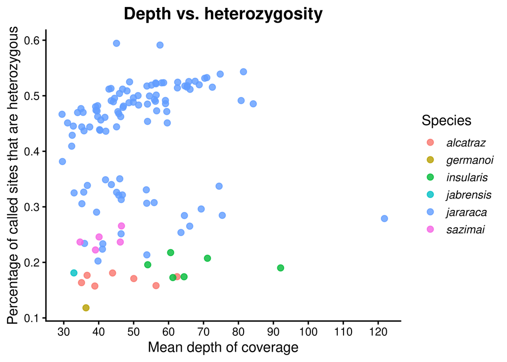

### Heterozygosity and sequencing batch

Within *B. jararaca*, heterozygosity and singleton counts are higher in the 605 batch, which is also deeper, so this has the shape of an allele-dropout artifact. It is not one: within *jararaca*, depth barely correlates with heterozygosity, and the difference follows sampling locality, which is confounded with batch (RS, RJ and PR are almost entirely 705; SC and ES mostly 605). Adding batch on top of `state` explains nothing further, while depth and missingness keep a strong batch effect after conditioning on state. The *state* comparison in 05c therefore needs the most care.

B. jararaca by state and batch

| state | seq batch | n | pct het | mean dp | n singletons |
| --- | --- | --- | --- | --- | --- |
| BA | 605_HCTGLBCXX | 3 | 0.373 | 60.087 | 993.333 |
| BA | 705_H2HLLBCXY | 1 | 0.477 | 34.930 | 309.000 |
| ES | 605_HCTGLBCXX | 6 | 0.502 | 57.825 | 441.500 |
| ES | 705_H2HLLBCXY | 2 | 0.505 | 50.305 | 468.500 |
| MG | 605_HCTGLBCXX | 10 | 0.477 | 58.658 | 341.700 |
| MG | 705_H2HLLBCXY | 10 | 0.467 | 41.511 | 308.600 |
| PR | 705_H2HLLBCXY | 4 | 0.364 | 39.195 | 254.500 |
| RJ | 605_HCTGLBCXX | 1 | 0.488 | 49.900 | 315.000 |
| RJ | 705_H2HLLBCXY | 10 | 0.470 | 39.019 | 344.800 |
| RS | 605_HCTGLBCXX | 1 | 0.337 | 74.460 | 80.000 |
| RS | 705_H2HLLBCXY | 13 | 0.278 | 46.002 | 68.385 |
| SC | 605_HCTGLBCXX | 16 | 0.415 | 61.730 | 257.000 |
| SC | 705_H2HLLBCXY | 3 | 0.408 | 39.443 | 331.000 |
| SP | 605_HCTGLBCXX | 18 | 0.506 | 57.959 | 324.444 |
| SP | 705_H2HLLBCXY | 7 | 0.462 | 42.589 | 278.429 |

Sex calls and locus filters are not affected: the Z:autosome depth ratio is a within-sample ratio and matches between batches, and the per-locus ordering of heterozygosity and missingness is preserved across batches.

## 14 Variant quality per sample

Real SNPs have a transition:transversion ratio of ~2, whereas random calls have 0.5.

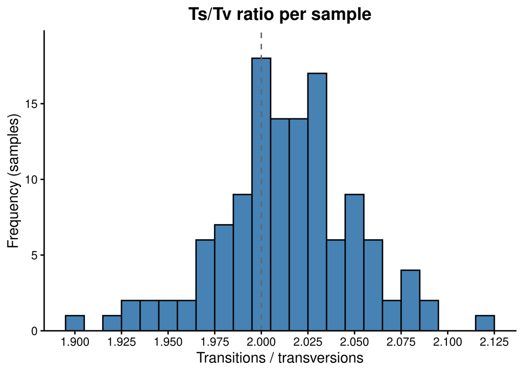

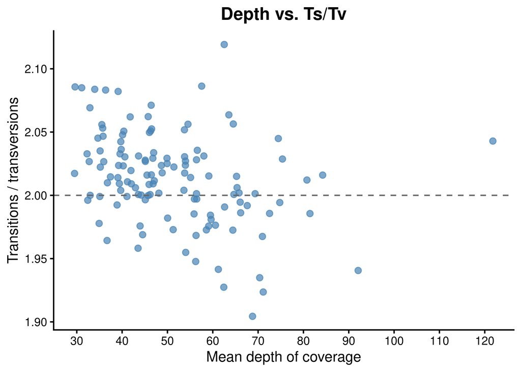

Private alleles are the other signature of contamination, so a sample far above its peers is worth a look even when its Ts/Tv is normal. Read them next to missingness: a sample with more sites called than its peers has more opportunity to carry a private allele, so the count is not purely a contamination signal.

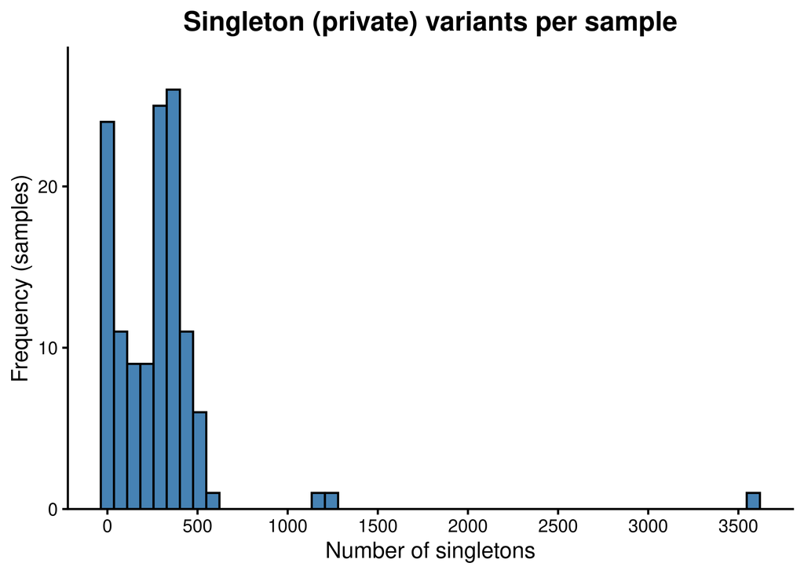

### The singleton outlier: I20937

| species | n samples | median singletons | median pct on target | median enrichment |
| --- | --- | --- | --- | --- |
| jabrensis | 1 | 3,583.00 | 9.73 | 68.60 |
| jararaca | 105 | 317.00 | 15.36 | 108.30 |
| germanoi | 1 | 143.00 | 19.21 | 135.50 |
| sazimai | 5 | 42.00 | 18.35 | 129.40 |
| alcatraz | 7 | 11.00 | 9.69 | 68.40 |
| insularis | 6 | 2.50 | 18.38 | 129.60 |

It does not look contaminated: heterozygosity is among the lowest in the panel (0.18% vs a median of 0.46%) and Ts/Tv is normal (2.07). Capture is typical for its batch (705: 9.7% on target, rank 14 of 57), but its error rate (0.0197) and missingness (7.7%) are the highest in the panel, consistent with reads diverging from the reference. Usable, but expect it to look artificially diverged and homozygous against the *jararaca* bulk.

## 15 Samples to watch

Every section above flags its own outliers. This pulls them into one list, so that a sample failing on several counts is visible as such rather than appearing once in each table. The thresholds are deliberately loose — this is a list to look at, not a filter.

The quantiles are taken **within** each sequencing batch. Panel-wide thresholds cut the tail of a bimodal distribution instead of finding outliers, so they mostly selected a batch: of the seven samples flagged for low depth all seven were 705, of the seven flagged for high duplication all seven were 605, and the singleton and Ts/Tv flags went 6 of 7 to 605. A within-batch quantile asks the question that was meant — whether a sample is unusual next to the samples it was sequenced with.

| sample | species | seq batch | n flags | mean dp | mean pct N final | ts tv | n singletons | pct duplication | pct mapped | pct blanked | median ab |
| --- | --- | --- | --- | --- | --- | --- | --- | --- | --- | --- | --- |
| I1507 | jararaca | 605_HCTGLBCXX | 5 | 33.96 | 7.04 | 2.08 | 376 | 4.42 | 99.29 | 9.03 | 0.44 |
| I12279 | alcatraz | 705_H2HLLBCXY | 3 | 62.43 | 2.13 | 1.93 | 11 | 7.53 | 99.39 | 0.89 | 0.49 |
| I1495 | jararaca | 605_HCTGLBCXX | 3 | 57.55 | 3.11 | 2.09 | 502 | 5.16 | 99.20 | 10.08 | 0.37 |
| I1624 | jararaca | 705_H2HLLBCXY | 3 | 39.54 | 5.49 | 2.03 | 312 | 2.46 | 99.49 | 12.23 | 0.43 |
| I20937 | jabrensis | 705_H2HLLBCXY | 3 | 32.90 | 7.66 | 2.07 | 3,583 | 3.65 | 99.45 | 1.78 | 0.50 |
| I12294 | jararaca | 705_H2HLLBCXY | 2 | 42.04 | 4.79 | 2.01 | 462 | 6.08 | 99.04 | 0.81 | 0.50 |
| I1230 | jararaca | 705_H2HLLBCXY | 2 | 31.09 | 7.06 | 2.08 | 350 | 3.55 | 99.41 | 1.18 | 0.50 |
| I1485 | insularis | 605_HCTGLBCXX | 2 | 71.13 | 1.28 | 1.92 | 2 | 5.58 | 98.04 | 0.90 | 0.50 |
| I1517 | jararaca | 705_H2HLLBCXY | 2 | 45.10 | 3.43 | 2.03 | 367 | 2.79 | 99.36 | 10.13 | 0.38 |
| I1528 | jararaca | 705_H2HLLBCXY | 2 | 29.62 | 7.60 | 2.09 | 313 | 2.88 | 99.37 | 1.55 | 0.48 |
| I1671 | jararaca | 705_H2HLLBCXY | 2 | 39.23 | 3.80 | 2.02 | 383 | 2.74 | 99.35 | 5.26 | 0.45 |
| I1684 | insularis | 605_HCTGLBCXX | 2 | 92.07 | 2.29 | 1.94 | 17 | 7.84 | 99.52 | 19.93 | 0.48 |
| I1723 | sazimai | 605_HCTGLBCXX | 2 | 34.66 | 7.23 | 2.05 | 21 | 4.67 | 99.10 | 1.11 | 0.49 |
| I1795 | jararaca | 605_HCTGLBCXX | 2 | 53.75 | 3.33 | 2.05 | 1,229 | 4.98 | 99.18 | 0.84 | 0.49 |
| I18357 | jararaca | 705_H2HLLBCXY | 2 | 29.51 | 6.69 | 2.02 | 386 | 3.25 | 98.20 | 1.82 | 0.50 |

Which checks each listed sample failed:

| sample | n flags | failed |
| --- | --- | --- |
| I1507 | 5 | low depth, high missingness, many hets blanked, low allele balance, sex not confident |
| I12279 | 3 | low Ts/Tv, high duplication, sex not confident |
| I1495 | 3 | many hets blanked, low allele balance, sex not confident |
| I1624 | 3 | many hets blanked, low allele balance, sex not confident |
| I20937 | 3 | high missingness, many singletons, sex not confident |
| I12294 | 2 | many singletons, high duplication |
| I1230 | 2 | low depth, high missingness |
| I1485 | 2 | low Ts/Tv, low mapping |
| I1517 | 2 | many hets blanked, low allele balance |
| I1528 | 2 | low depth, high missingness |
| I1671 | 2 | low allele balance, sex not confident |
| I1684 | 2 | low Ts/Tv, many hets blanked |
| I1723 | 2 | low depth, high missingness |
| I1795 | 2 | many singletons, sex not confident |
| I18357 | 2 | low depth, low mapping |

The two allele-balance flags and the sex-calling flag keep landing on the same samples, and they are measured independently: allele balance on the autosomal loci, sex from Z depth and Z heterozygosity. Of the 7 samples with low median allele balance for their batch, 4 are also ‘sex not confident’, against 3 of the other 118 (Fisher’s exact test, p = 1e-04). How they fail is consistent with a second source of DNA:

- **I1495 and I1507** are females whose Z depth ratio is well above the female norm (0.57 and 0.53, against a female median of 0.43), which is what reads from a male would add.
- **I1624** is a male flagged on both its depth ratio and its heterozygous gametolog sites.
- **I1671** fits the same pattern more weakly: a female with a raised depth ratio (0.48) and low balance for its batch.
- Among females, the three with the lowest allele balance — I1495, I1507, and I1520 — have three of the four highest Z het densities, all above the 95th percentile for females. A ZW female should have essentially no Z heterozygosity.

None of these samples is among those flagged as contaminated in the metadata. I1495, I1507, and I1624, and I1517 on allele balance alone, are the ones to check first. The three samples with the most hets blanked (I1768, I1670, I1684) are not low in allele balance and have confident sex calls, and their balance is centered on 0.5, so they do not share this pattern.

## 16 Metadata-flagged samples

The 52 samples flagged as contaminated in the metadata were removed in 03c, before any locus filter, and their stats come from side runs (step 4I). Singleton counts and sex-call confidence depend on which samples are scored together, so in this section both groups take them from the 4I runs, which scored all 177 samples together; elsewhere in this report the retained samples’ values come from runs without the flagged samples. A second DNA source should show as a lower median allele balance, more hets below 0.35, and more sex calls that are not confident.

Medians, flagged vs. retained samples

| group | n | mean dp | mean pct N final | het pct final | ab median | ab pct below 0.35 | ab pct blanked | n singletons | ts tv | pct sex not confident |
| --- | --- | --- | --- | --- | --- | --- | --- | --- | --- | --- |
| retained | 125 | 46.96 | 3.13 | 0.46 | 0.49 | 6.76 | 0.89 | 241.00 | 2.01 | 4.00 |
| flagged | 52 | 37.63 | 5.47 | 0.43 | 0.49 | 9.34 | 1.58 | 139.50 | 2.04 | 23.08 |

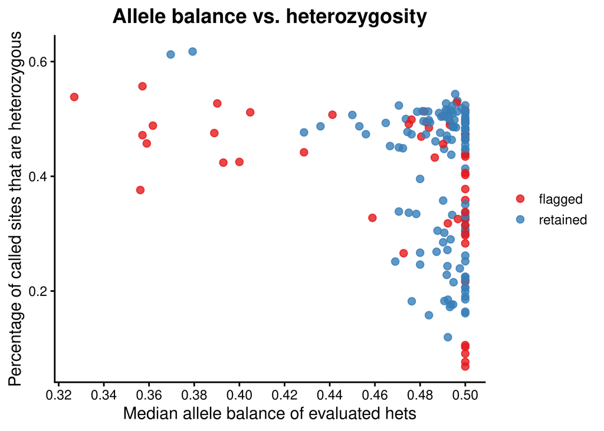

13 of the 52 flagged samples have a median allele balance below 0.45, against 4 of the 125 retained samples. The flagged samples with low balance or a sex call that is not confident are below. Most of the second kind combine a balance of exactly 0.5 with very few hets and a lot of missing data. Across all flagged samples, 17 of 52 have more than 10% missing data over the final loci, so the missingness filter would likely have removed them anyway.

| sample | species | seq batch | mean dp | mean pct N final | het pct final | ab median | ab pct below 0.35 | n singletons | sex confident |
| --- | --- | --- | --- | --- | --- | --- | --- | --- | --- |
| I1613 | jararaca | 605_HCTGLBCXX | 52.390 | 3.878 | 0.538 | 0.327 | 54.308 | 78 | TRUE |
| I1681 | insularis | 605_HCTGLBCXX | 58.120 | 3.341 | 0.376 | 0.356 | 48.753 | 32 | FALSE |
| I1622 | jararaca | 705_H2HLLBCXY | 37.210 | 5.664 | 0.472 | 0.357 | 47.827 | 62 | FALSE |
| I1683 | insularis | 605_HCTGLBCXX | 61.220 | 3.054 | 0.557 | 0.357 | 48.295 | 147 | TRUE |
| I1625 | jararaca | 705_H2HLLBCXY | 35.850 | 6.413 | 0.457 | 0.359 | 48.086 | 105 | FALSE |
| I1609 | jararaca | 705_H2HLLBCXY | 34.190 | 6.563 | 0.488 | 0.362 | 47.305 | 163 | FALSE |
| I1623 | jararaca | 705_H2HLLBCXY | 37.080 | 6.139 | 0.475 | 0.389 | 40.831 | 130 | FALSE |
| I1518 | jararaca | 605_HCTGLBCXX | 74.040 | 3.509 | 0.527 | 0.390 | 37.750 | 242 | TRUE |
| I1674 | alcatraz | 705_H2HLLBCXY | 51.830 | 3.678 | 0.424 | 0.393 | 43.308 | 39 | FALSE |
| I1754 | jararaca | 705_H2HLLBCXY | 21.820 | 15.090 | 0.425 | 0.400 | 39.794 | 29 | TRUE |
| I1611 | jararaca | 605_HCTGLBCXX | 68.240 | 3.430 | 0.512 | 0.405 | 33.219 | 271 | TRUE |
| I1807 | jararaca | 705_H2HLLBCXY | 17.840 | 29.468 | 0.442 | 0.429 | 31.376 | 117 | TRUE |
| I1618 | jararaca | 705_H2HLLBCXY | 46.310 | 3.810 | 0.507 | 0.441 | 21.246 | 396 | TRUE |
| I1554 | jararaca | 705_H2HLLBCXY | 31.630 | 21.518 | 0.216 | 0.500 | 9.000 | 72 | FALSE |
| I1557 | jararaca | 705_H2HLLBCXY | 15.860 | 56.284 | 0.283 | 0.500 | 12.825 | 92 | FALSE |
| I1639 | jararaca | 705_H2HLLBCXY | 22.340 | 41.811 | 0.219 | 0.500 | 9.349 | 20 | FALSE |
| I1774 | germanoi | 605_HCTGLBCXX | 15.750 | 48.194 | 0.106 | 0.500 | 17.222 | 52 | FALSE |
| I1775 | germanoi | 605_HCTGLBCXX | 11.870 | 64.387 | 0.076 | 0.500 | 12.478 | 5 | FALSE |
| I18405 | jararaca | 705_H2HLLBCXY | 24.540 | 19.527 | 0.068 | 0.500 | 10.000 | 43 | FALSE |